# Born at Risk: A Data-Driven Analysis of Global Inequalities in HIV Transmission and Adolescent Motherhood

Author

Susmita Das

Published

April 14, 2026

```python
# Install required packages
!pip install -q plotnine geopandas scipy geodatasets polars
```

```python
import polars as pl
import numpy as np
import geopandas as gpd
import matplotlib
%matplotlib inline
import matplotlib.pyplot as plt
import matplotlib.patches as mpatches
from matplotlib.colors import LinearSegmentedColormap
from plotnine import *
from scipy import stats
import warnings
warnings.filterwarnings('ignore')

# ── Load data ─────────────────────────────────────────────────────────────
ind1 = pl.read_csv('/content/drive/MyDrive/unicef_indicator_1.csv')
ind2 = pl.read_csv('/content/drive/MyDrive/unicef_indicator_2.csv')
meta = pl.read_csv('/content/drive/MyDrive/unicef_metadata.csv')

# ── HIV: latest value per country (Total sex only) ────────────────────────
hiv_latest = (
    ind1.filter(pl.col('sex') == 'Total')
    .sort('time_period')
    .group_by(['country', 'alpha_3_code'])
    .last()
    .select(['country', 'alpha_3_code', 'time_period', 'obs_value'])
    .rename({'obs_value': 'hiv_rate', 'time_period': 'hiv_year'})
)

# ── HIV: global average + std range by year ───────────────────────────────
hiv_trend = (
    ind1.filter(pl.col('sex') == 'Total')
    .group_by('time_period')
    .agg([
        pl.col('obs_value').mean().alias('avg_hiv'),
        pl.col('obs_value').min().alias('min'),
        pl.col('obs_value').max().alias('max'),
        pl.col('obs_value').std().alias('std'),
    ])
    .sort('time_period')
    .rename({'time_period': 'year'})
    .with_columns([
        (pl.col('avg_hiv') - pl.col('std')).alias('ymin'),
        (pl.col('avg_hiv') + pl.col('std')).alias('ymax'),
    ])
)

# ── Metadata: latest GDP + life expectancy per country ────────────────────
meta_latest = (
    meta
    .drop_nulls(subset=['GDP per capita (constant 2015 US$)',
                        'Life expectancy at birth, total (years)'])
    .sort('year', descending=True)
    .group_by('alpha_3_code')
    .first()
    .select(['alpha_3_code',
             'GDP per capita (constant 2015 US$)',
             'Life expectancy at birth, total (years)',
             'Population, total'])
    .rename({
        'GDP per capita (constant 2015 US$)': 'gdp',
        'Life expectancy at birth, total (years)': 'life_exp',
        'Population, total': 'population'
    })
)

# ── Scatter dataset ───────────────────────────────────────────────────────
scatter_df = (
    hiv_latest
    .join(meta_latest, on='alpha_3_code', how='inner')
    .drop_nulls(subset=['gdp', 'life_exp'])
    .with_columns([
        pl.col('gdp').log(10).alias('gdp_log'),
        pl.when(pl.col('gdp') <= 1000).then(pl.lit('Low (<$1k)'))
          .when(pl.col('gdp') <= 5000).then(pl.lit('Lower-Middle ($1k-$5k)'))
          .when(pl.col('gdp') <= 15000).then(pl.lit('Upper-Middle ($5k-$15k)'))
          .otherwise(pl.lit('High (>$15k)')).alias('income_group')
    ])
)

# ── Bar chart: top 20 countries ───────────────────────────────────────────
bar_df = (
    hiv_latest
    .sort('hiv_rate', descending=True)
    .head(20)
    .sort('hiv_rate', descending=False)
)

# ── Regression stats ──────────────────────────────────────────────────────
slope, intercept, r_val, p_val, se = stats.linregress(
    scatter_df['gdp_log'].to_numpy(),
    scatter_df['hiv_rate'].to_numpy()
)

# ── Reduction stat ────────────────────────────────────────────────────────
start_val = hiv_trend.sort('year').row(0, named=True)['avg_hiv']
end_val   = hiv_trend.sort('year').row(-1, named=True)['avg_hiv']
reduction = ((start_val - end_val) / start_val) * 100

print('Setup complete')
print(f'  HIV countries : {len(hiv_latest)}')
print(f'  Scatter points: {len(scatter_df)}')
print(f'  R value       : {r_val:.3f}')
print(f'  Reduction     : {reduction:.1f}%')
```

```
Setup complete
  HIV countries : 82
  Scatter points: 81
  R value       : -0.336
  Reduction     : 38.9%
```

## Born at Risk: A Data-Driven Analysis of HIV Transmission and Adolescent Motherhood Inequality

Every year, hundreds of thousands of children enter the world already living with HIV—not due to any decision of their own, but because the systems designed to protect them have failed. At the same time, millions of girls in the world’s poorest regions become mothers far too early—before they are physically ready, and before they have the ability or autonomy to make that choice for themselves.

These two challenges—mother-to-child HIV transmission and high adolescent birth rates—are deeply interconnected rather than separate issues. Both are rooted in the same underlying factors: poverty, limited access to healthcare, and the persistent marginalization of girls and women from education and economic opportunities.

## Chart 1 - Where You’re Born Matters: A Global Map of HIV Transmission Risk

The map below shows the **mother-to-child HIV transmission rate** for each country. *Darker colours represent higher transmission rates. Grey = no data.*

```
Total countries: 258
Countries with HIV data: 82
```

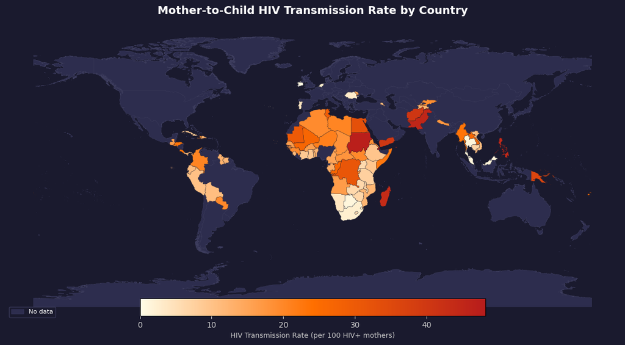

```
Map rendered successfully
```

```python
import requests
import geopandas as gpd

url = 'https://raw.githubusercontent.com/datasets/geo-countries/master/data/countries.geojson'
world = gpd.read_file(url)

# Rename the correct column
world = world.rename(columns={'ISO3166-1-Alpha-3': 'alpha_3_code'})
map_df = world.merge(
    hiv_latest.select(['alpha_3_code', 'hiv_rate']).to_pandas(),
    on='alpha_3_code', how='left'
)

print(f"Total countries: {len(map_df)}")
print(f"Countries with HIV data: {map_df['hiv_rate'].notna().sum()}")

fig, ax = plt.subplots(1, 1, figsize=(14, 7))
fig.patch.set_facecolor('#1a1a2e')
ax.set_facecolor('#1a1a2e')

map_df[map_df['hiv_rate'].isna()].plot(
    ax=ax, color='#2d2d4e', edgecolor='#3d3d5e', linewidth=0.3
)

cmap = LinearSegmentedColormap.from_list(
    'hiv_map', ['#fffde7', '#ff6f00', '#b71c1c']
)
valid = map_df.dropna(subset=['hiv_rate'])
valid.plot(
    column='hiv_rate', ax=ax, cmap=cmap,
    edgecolor='#1a1a2e', linewidth=0.2,
    vmin=0, vmax=valid['hiv_rate'].max()
)

sm = plt.cm.ScalarMappable(
    cmap=cmap,
    norm=plt.Normalize(vmin=0, vmax=valid['hiv_rate'].max())
)
sm.set_array([])
cbar = fig.colorbar(sm, ax=ax, shrink=0.45, pad=0.02,
                    orientation='horizontal', anchor=(0.5, 1.8))
cbar.set_label('HIV Transmission Rate (per 100 HIV+ mothers)',
               color='#cccccc', fontsize=9)
cbar.ax.xaxis.set_tick_params(color='#cccccc', labelcolor='#cccccc')

ax.set_title('Mother-to-Child HIV Transmission Rate by Country',
             fontsize=14, color='white', fontweight='bold', pad=12)
ax.axis('off')

no_data_patch = mpatches.Patch(color='#2d2d4e', label='No data')
ax.legend(handles=[no_data_patch], loc='lower left',
          facecolor='#1a1a2e', edgecolor='#3d3d5e',
          labelcolor='white', fontsize=8)

plt.tight_layout()
plt.savefig('map_output.png', dpi=100, bbox_inches='tight', facecolor='#1a1a2e')
plt.show()
print("Map rendered successfully")
```

## Chart 2 - A Stark Divide: HIV Transmission Risk in the World’s Most Affected Countries

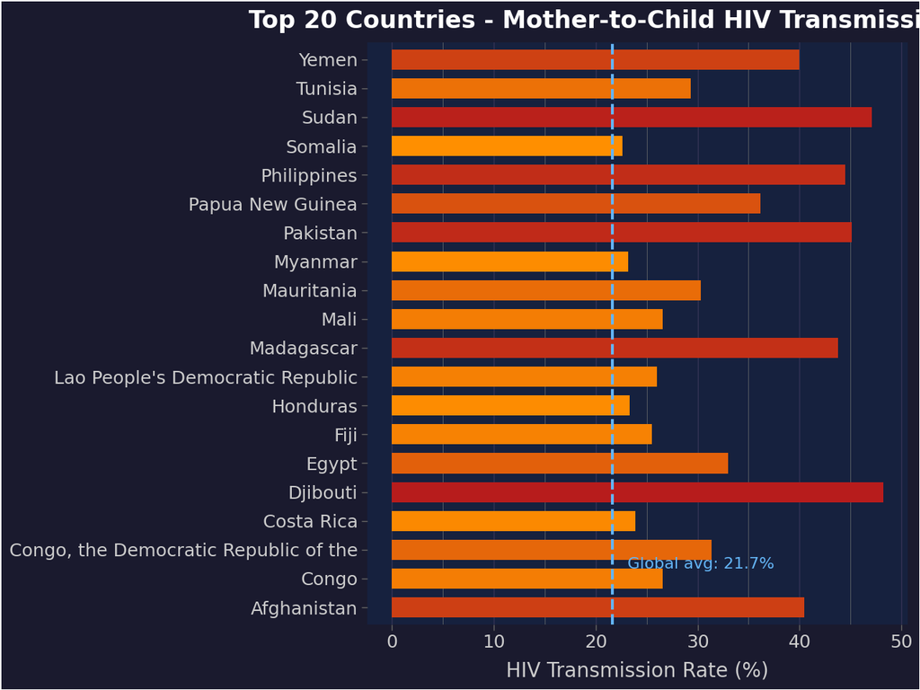

```python
global_avg = ind1.filter(pl.col('sex') == 'Total')['obs_value'].mean()

(
    ggplot(bar_df, aes(x='country', y='hiv_rate', fill='hiv_rate'))
    + geom_col(width=0.7, show_legend=False)
    + geom_hline(yintercept=global_avg,
                 linetype='dashed', color='#64b5f6', size=0.8)
    + annotate('text', x=2.5, y=global_avg + 1.5,
               label=f'Global avg: {global_avg:.1f}%',
               color='#64b5f6', size=8, ha='left')
    + scale_fill_gradient(low='#ff8f00', high='#b71c1c')
    + coord_flip()
    + labs(
        title='Top 20 Countries - Mother-to-Child HIV Transmission Rate',
        x='',
        y='HIV Transmission Rate (%)'
    )
    + theme_dark()
    + theme(
        plot_background=element_rect(fill='#1a1a2e'),
        panel_background=element_rect(fill='#16213e'),
        panel_grid_major_y=element_blank(),
        panel_grid_major_x=element_line(color='#333355'),
        axis_text=element_text(color='#cccccc', size=9),
        axis_title=element_text(color='#cccccc', size=10),
        plot_title=element_text(color='white', size=12, face='bold'),
    )
)
```

## Chart 3 - Wealth and Survival: How Income Levels Shape HIV Transmission Risk

[figure not shown]

```python
x_max = float(scatter_df['gdp_log'].drop_nulls().max())
y_max = float(scatter_df['hiv_rate'].drop_nulls().max())

(
    ggplot(scatter_df, aes(x='gdp_log', y='hiv_rate', color='income_group'))
    + geom_point(size=2.5, alpha=0.85)
    + geom_smooth(aes(group=1), method='lm',
                  color='white', linetype='dashed',
                  size=0.9, se=True, alpha=0.15)
    + annotate('text',
               x=x_max - 0.1,
               y=y_max - 2,
               label=f'r = {r_val:.2f}   p < 0.001',
               color='#aaaaaa', size=8, ha='right')
    + scale_color_manual(
        values={
            'Low (<$1k)':              '#ef5350',
            'Lower-Middle ($1k-$5k)':  '#ff8f00',
            'Upper-Middle ($5k-$15k)': '#66bb6a',
            'High (>$15k)':            '#42a5f5',
        }
    )
    + scale_x_continuous(
        breaks=[2.5, 3.0, 3.5, 4.0, 4.5, 5.0],
        labels=['$316', '$1k', '$3.2k', '$10k', '$32k', '$100k']
    )
    + labs(
        title='Wealthier Countries Have Lower HIV Transmission Rates',
        x='GDP per Capita (log scale, constant 2015 USD)',
        y='HIV Transmission Rate (%)',
        color='Income Group'
    )
    + theme_dark()
    + theme(
        plot_background=element_rect(fill='#1a1a2e'),
        panel_background=element_rect(fill='#16213e'),
        panel_grid=element_line(color='#2a2a4a'),
        axis_text=element_text(color='#aaaaaa', size=9),
        axis_title=element_text(color='#cccccc', size=10),
        plot_title=element_text(color='white', size=12, face='bold'),
        legend_background=element_rect(fill='#1a1a2e'),
        legend_text=element_text(color='#cccccc', size=8),
        legend_title=element_text(color='#aaaaaa', size=9),
    )
)
```

## Chart 4 - Progress Uneven: Global Trends in HIV Transmission (2010–2024)

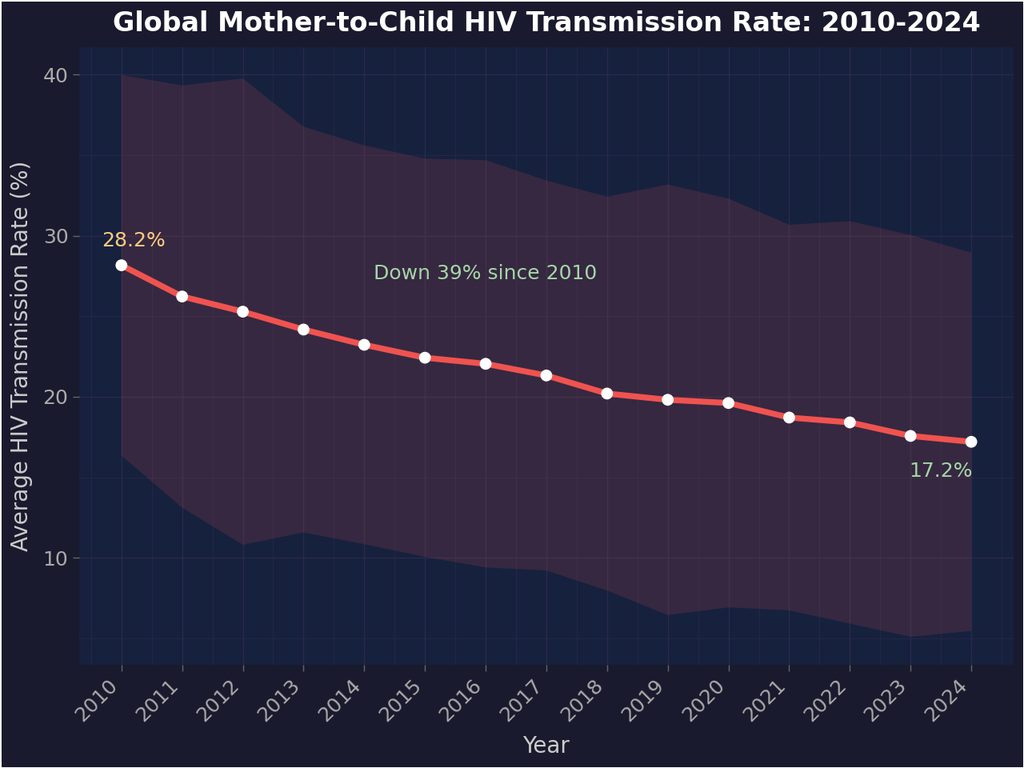

```python
hiv_sorted = hiv_trend.sort('year')

(
    ggplot(hiv_sorted, aes(x='year', y='avg_hiv'))
    + geom_ribbon(aes(ymin='ymin', ymax='ymax'),
                  fill='#ef5350', alpha=0.15)
    + geom_line(color='#ef5350', size=1.5)
    + geom_point(color='white', size=2, shape='o')
    + annotate('text',
               x=hiv_sorted['year'][0] + 0.2,
               y=hiv_sorted['avg_hiv'][0] + 1.5,
               label=f'{start_val:.1f}%',
               color='#ffcc80', size=9)
    + annotate('text',
               x=hiv_sorted['year'][-1] - 0.5,
               y=hiv_sorted['avg_hiv'][-1] - 1.8,
               label=f'{end_val:.1f}%',
               color='#a5d6a7', size=9)
    + annotate('text',
               x=2016, y=hiv_sorted['avg_hiv'].max() - 0.5,
               label=f'Down {reduction:.0f}% since 2010',
               color='#a5d6a7', size=9)
    + scale_x_continuous(breaks=list(range(2010, 2025)))
    + labs(
        title='Global Mother-to-Child HIV Transmission Rate: 2010-2024',
        x='Year',
        y='Average HIV Transmission Rate (%)'
    )
    + theme_dark()
    + theme(
        plot_background=element_rect(fill='#1a1a2e'),
        panel_background=element_rect(fill='#16213e'),
        panel_grid=element_line(color='#2a2a4a'),
        axis_text=element_text(color='#aaaaaa', size=9),
        axis_text_x=element_text(angle=45, hjust=1),
        axis_title=element_text(color='#cccccc', size=10),
        plot_title=element_text(color='white', size=12, face='bold'),
    )
)
```

## What the Data Demands

The evidence presented throughout this analysis leads to a clear and unavoidable conclusion: mother-to-child HIV transmission is largely preventable, yet it persists due to gaps in access, investment, and accountability. The data does not reflect a lack of knowledge or medical capability, but rather highlights where systems, policies, and resources have failed to reach those most in need.

While global progress has been made, it remains uneven and insufficient. The continued concentration of high transmission rates in the world’s poorest regions underscores the urgent need for more targeted and sustained intervention. Ensuring universal access to antiretroviral treatment for HIV-positive pregnant women must be a fundamental priority. At the same time, strengthening healthcare infrastructure in low-income countries is essential to deliver these interventions effectively and consistently.

Equally important is the role of education and empowerment of girls, which remains one of the most impactful and cost-effective strategies for breaking the cycle of poverty, early motherhood, and health vulnerability. Without addressing these underlying social determinants, progress will remain fragile.

Finally, there is a need for stronger accountability mechanisms. Success should not be measured solely through global averages, but through the extent to which the most vulnerable populations are reached and supported.

Ultimately, the data presents both a warning and a roadmap. It shows how far progress has come, but more importantly, it reveals what must be done next. Every child has the right to be born healthy—and achieving this is not a question of possibility, but of priority and action.

## Data Sources

| Dataset | Description | Coverage |
| --- | --- | --- |
| `unicef_indicator_1.csv` | Mother-to-child HIV transmission rate | 82 countries, 2010-2024 |
| `unicef_indicator_2.csv` | Adolescent birth rate | 223 countries, 2000-2023 |
| `unicef_metadata.csv` | GDP per capita, life expectancy | Global, 1960-2024 |

*All data sourced from UNICEF Data Warehouse and World Bank development indicators.*